# Исследование объявлений о продаже квартир

#### Последняя цена и количество комнат

```
0.3647507855592098
```

| rooms | median last_price | count last_price |
| --- | --- | --- |
| 0 | 2800000 | 147 |
| 1 | 3600000 | 8035 |
| 2 | 4750000 | 7871 |
| 3 | 6200000 | 5760 |
| 4 | 9000000 | 1166 |
| 5 | 13900000 | 321 |
| 6 | 19000000 | 105 |
| 7 | 24900000 | 57 |
| 8 | 23095000 | 12 |
| 9 | 23750000 | 8 |
| 10 | 23000000 | 3 |
| 11 | 25250000 | 2 |
| 12 | 245500000 | 2 |
| 14 | 26829500 | 2 |
| 15 | 65000000 | 1 |
| 16 | 28500000 | 1 |
| 19 | 32250000 | 1 |

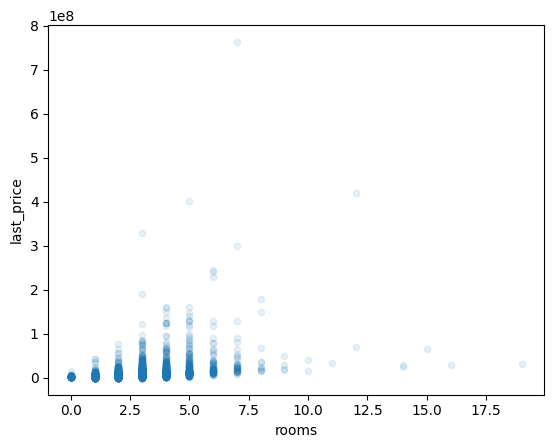

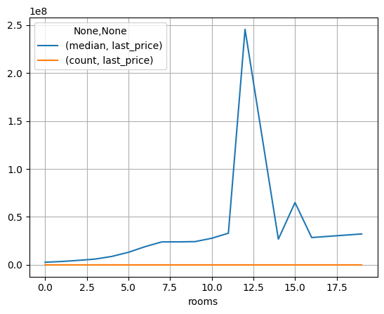

```python
display (data['last_price'].corr(data['rooms']))
display(data.pivot_table(index='rooms', values='last_price', aggfunc=['median', 'count']))
data.query('days_exposition >0').plot(x='rooms', y='last_price', kind='scatter', alpha=0.1)
plt.show()

(data
     .query('days_exposition >0')
     .pivot_table(index='rooms', values='last_price', aggfunc=['median', 'count'])
     .plot(grid=True)
)
plt.show()
```

**Вывод**: Общая тенденция, что с увеличением числа комнат растет цена. Наиболее интенсивный рост последней цены в диапозоне трех - семи комнат. А количество сделок в этом диапозоне падает.

#### Последняя цена и тип этажа

| floor_type | median last_price | mean last_price | count last_price |
| --- | --- | --- | --- |
| другой | 4835000 | 6.661994e+06 | 17225 |
| первый | 3900000 | 4.789659e+06 | 2891 |
| последний | 4300000 | 7.296797e+06 | 3294 |

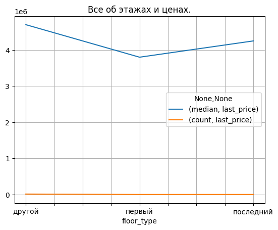

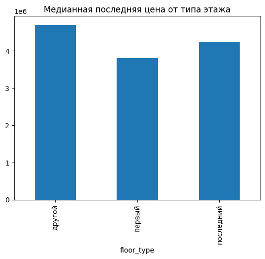

```python
# display (data['last_price'].corr(data['floor_type']))
display(data.pivot_table(index='floor_type', values='last_price', aggfunc=['median', 'mean', 'count']))



(data
     .query('days_exposition >0')
     .pivot_table(index='floor_type', values='last_price', aggfunc=['median', 'count'])
     .plot(grid=True, title='Все об этажах и ценах.')
)
plt.show()

(data.query('days_exposition >0')
     .groupby('floor_type')['last_price']
     .median()
     .plot(kind='bar', title='Медианная последняя цена от типа этажа')
)
plt.show()
```

**Вывод**: Первые этажи самые дешёвые. Медиана цены для последних этажей средняя между первыми и другими этажами, а вот средняя самая высокая. Наверное, кто то стал ценить мансарды.

#### Последняя цена и день недели размещения

```
0.0019716600311731943
```

| weekday_exposition | median last_price | mean last_price | count last_price |
| --- | --- | --- | --- |
| 0 | 4635000 | 6.494667e+06 | 3578 |
| 1 | 4700000 | 6.373968e+06 | 4143 |
| 2 | 4700000 | 6.607319e+06 | 3938 |
| 3 | 4650000 | 6.654715e+06 | 4262 |
| 4 | 4550000 | 6.353955e+06 | 3967 |
| 5 | 4567500 | 6.972108e+06 | 1924 |
| 6 | 4550000 | 6.259489e+06 | 1682 |

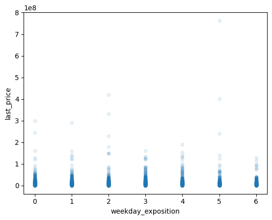

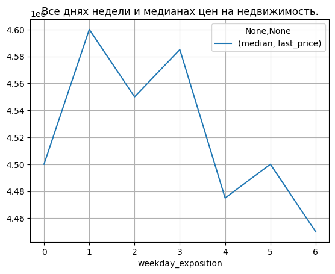

```python
display (data['last_price'].corr(data['weekday_exposition']))
display(data.pivot_table(index='weekday_exposition', values='last_price', aggfunc=['median', 'mean', 'count']))
data.plot(x='weekday_exposition', y='last_price', kind='scatter', alpha=0.1)
plt.show()

(data
     .query('days_exposition >0')
     .pivot_table(index='weekday_exposition', values='last_price', aggfunc=['median'])
     .plot(grid=True, title='Все днях недели и медианах цен на недвижимость.')
)
plt.show()
```

#### Последняя цена и месяц размещения

```
0.0017388739669117192
```

| month_exposition | median last_price | mean last_price | count last_price |
| --- | --- | --- | --- |
| 1 | 4600000 | 6.646557e+06 | 1487 |
| 2 | 4650000 | 6.441526e+06 | 2618 |
| 3 | 4650000 | 6.356109e+06 | 2569 |
| 4 | 4800000 | 6.740632e+06 | 2360 |
| 5 | 4540000 | 6.611450e+06 | 1260 |
| 6 | 4400000 | 6.291294e+06 | 1744 |
| 7 | 4600000 | 6.629835e+06 | 1676 |
| 8 | 4570000 | 6.326270e+06 | 1733 |
| 9 | 4700000 | 6.795316e+06 | 1963 |
| 10 | 4550000 | 6.220291e+06 | 2103 |
| 11 | 4690000 | 6.382503e+06 | 2353 |
| 12 | 4690000 | 6.987815e+06 | 1628 |

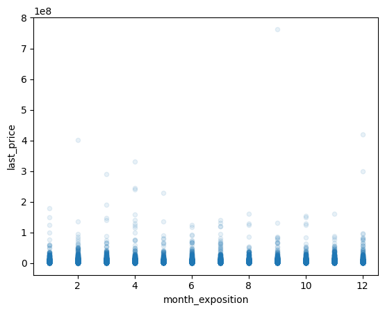

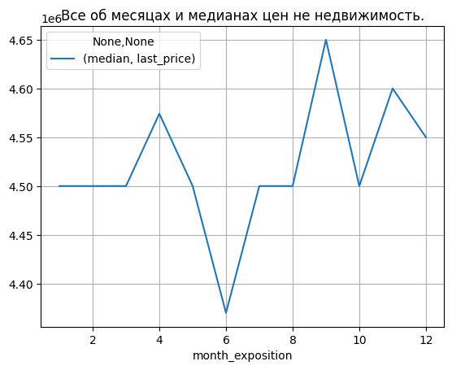

```python
display (data['last_price'].corr(data['month_exposition']))
display(data.pivot_table(index='month_exposition', values='last_price', aggfunc=['median', 'mean', 'count']))
data.plot(x='month_exposition', y='last_price', kind='scatter', alpha=0.1)
plt.show()

(data
     .query('days_exposition >0')
     .pivot_table(index='month_exposition', values='last_price', aggfunc=['median'])
     .plot(grid=True, title='Все об месяцах и медианах цен не недвижимость.')
)
plt.show()
```

**Вывод**: Краткость сестра таланта:

Когда анализируем можно делать сделки в обе стороны. Но, если вы новичек на рынке недвижимости, то смотрите выше.

#### Последняя цена и год размещения

```
-0.04198865098295504
```

| year_exposition | median last_price | mean last_price | sum last_price | count last_price |
| --- | --- | --- | --- | --- |
| 2014 | 8037000 | 1.221050e+07 | 1.623996e+09 | 133 |
| 2015 | 5300000 | 8.484773e+06 | 9.842336e+09 | 1160 |
| 2016 | 4550000 | 6.814582e+06 | 1.871284e+10 | 2746 |
| 2017 | 4500000 | 6.569376e+06 | 5.344844e+10 | 8136 |
| 2018 | 4550000 | 5.929018e+06 | 5.013578e+10 | 8456 |
| 2019 | 5050000 | 6.780588e+06 | 1.941282e+10 | 2863 |

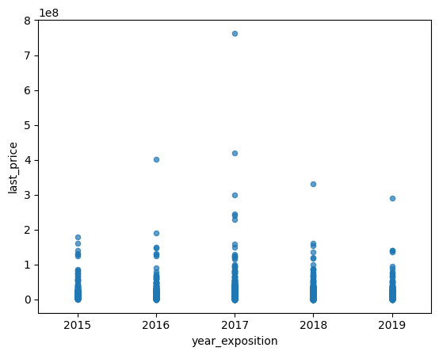

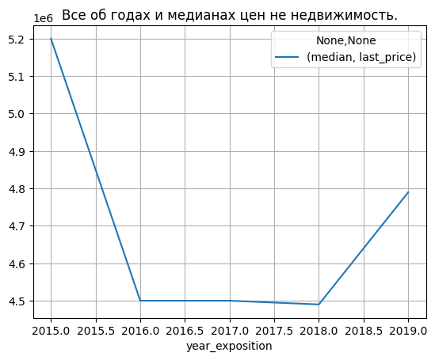

```python
display (data['last_price'].corr(data['year_exposition']))
display(data.pivot_table(index='year_exposition', values='last_price', aggfunc=['median', 'mean', 'sum', 'count']))
data.plot(x='year_exposition', y='last_price', kind='scatter', alpha=0.7, xlim=(2014.5, 2019.5))
plt.show()

(data
     .query('days_exposition >0 and year_exposition > 2014')
     .pivot_table(index='year_exposition', values='last_price', aggfunc=['median'])
     .plot(grid=True, title='Все об годах и медианах цен не недвижимость.')
)
plt.show()
```

**Вывод*:

- мы не должны учитывать 2014 год, так как слишком мало данных
- более низкие цны в 2016, 2017, 2018 годах позволили вырасти количеству сделок и общему объуму рынка
- в 2019 год цена начала снова расти, рынок уменьшился

Покупательскую способность не обманешь.

### Задание: Посчитайте среднюю цену одного квадратного метра в 10 населённых пунктах с наибольшим числом объявлений. Выделите населённые пункты с самой высокой и низкой стоимостью квадратного метра.

```python
top10_locations = data.query('days_exposition > 0') \
    .pivot_table(index='locality_name', values='sq_m_price', aggfunc=['sum', 'count']) \
    .sort_values(by=('count', 'sq_m_price'), ascending=False) \
    .head(10)
# display(top10_locations.columns)

top10_locations.columns = ['sum', 'count']
# display(top10_locations.columns)
#display(top10_locations)

# Конечно, средняя цена средних цен за квадратный метр это не совсем то, что нам нужно, но будет интересно сравнить
top10_locations['avr_avr_sq_m_price'] = top10_locations['sum'] / top10_locations['count']

# округлим и изменим тип данных
top10_locations['avr_avr_sq_m_price'] = np.ceil(pd.to_numeric(top10_locations['avr_avr_sq_m_price'], errors='coerce')).astype('Int64')
# display (top10_locations)

data_top10_locations = data.query('locality_name in @top10_locations.index and days_exposition > 0')
# data_top10_locations.head()

# можно решить через pivot_table как ниже, но хочется испытать цикл и groupby
# top10_locations['avr_sq_m_price'] = 0
for column_value, column_slice in data_top10_locations.groupby('locality_name'):
#    display(column_value, column_slice['last_price'].sum() / column_slice['total_area'].sum())
    top10_locations.loc[top10_locations.index == column_value, 'avr_sq_m_price'] = \
                    column_slice['last_price'].sum() / column_slice['total_area'].sum()


# округлим и изменим тип данных
top10_locations['avr_sq_m_price'] = np.ceil(pd.to_numeric(top10_locations['avr_sq_m_price'], errors='coerce')).astype('Int64')
top10_locations
```

| locality_name | sum | count | avr_avr_sq_m_price | avr_sq_m_price |
| --- | --- | --- | --- | --- |
| Санкт-Петербург | 1521522950 | 13549 | 112298 | 121749 |
| посёлок Мурино | 46765255 | 546 | 85651 | 83055 |
| Кудрово | 41634129 | 441 | 94409 | 92849 |
| посёлок Шушары | 31663311 | 406 | 77989 | 75600 |
| Всеволожск | 22995068 | 336 | 68438 | 67318 |
| Пушкин | 31162619 | 305 | 102173 | 103943 |
| Колпино | 22885627 | 305 | 75035 | 74030 |
| посёлок Парголово | 26927177 | 301 | 89460 | 86394 |
| Гатчина | 17882365 | 263 | 67994 | 67226 |
| Выборг | 11818475 | 207 | 57095 | 56503 |

В колонке `avr_sq_m_price` таблицы выше вы можете увидеть среднюю цену за 1 квадртаный метр недвижимости в 10 населенных пунктах где больше всего объявлений.

**Вывод 1**: Как вы видите самый активный и самый дорогой это Санкт-Петербург и его ближайшие окрестности. А Выборг из этой выборки имеет самые низкие цены на один квадратный метр нежвижимости.

Справочно, в стобце `avr_avr_sq_m_price`, мы посчитали среднюю средних цен каждой квартиры за один квадртаный метр. Как видите значения в столбцах отличаются в обе стороны. Вероятно эти различия связаны с неоднородностью цены одного квадратного метра по квартирам.

*Факультативно* сделаем расчеты средних цен для разнокомнатных квартир в этих же 10 населённых пунктах.

```python
data_top10_locations_pivot_table = \
data_top10_locations.pivot_table(index=['locality_name', 'studio', 'rooms']
                                 , values=['last_price', 'total_area']
                                 , aggfunc='sum')
data_top10_locations_pivot_table['avr_sq_m_price'] = data_top10_locations_pivot_table['last_price'] / \
                                                    data_top10_locations_pivot_table['total_area']

# округлим и изменим тип данных
data_top10_locations_pivot_table['avr_sq_m_price'] = \
np.ceil(pd.to_numeric(data_top10_locations_pivot_table['avr_sq_m_price'], errors='coerce')).astype('Int64')
# сделаем так, чтобы было видно все строки
pd.set_option('display.max_rows', None)
data_top10_locations_pivot_table
```

| locality_name | studio | rooms | last_price | total_area | avr_sq_m_price |
| --- | --- | --- | --- | --- | --- |
| Всеволожск | False | 1 | 3.614179e+08 | 4935.94 | 73222 |
|  |  | 2 | 4.707666e+08 | 6899.81 | 68229 |
|  |  | 3 | 3.549102e+08 | 5697.10 | 62297 |
|  |  | 4 | 3.962000e+07 | 697.00 | 56844 |
|  | True | 0 | 7.750000e+06 | 108.20 | 71627 |
| Выборг | False | 1 | 1.214490e+08 | 1984.30 | 61205 |
|  |  | 2 | 2.504470e+08 | 4423.40 | 56619 |
|  |  | 3 | 2.035900e+08 | 3659.30 | 55637 |
|  |  | 4 | 5.187700e+07 | 1009.80 | 51374 |
|  |  | 5 | 4.500000e+06 | 106.20 | 42373 |
| Гатчина | False | 1 | 2.294300e+08 | 3157.02 | 72673 |
|  |  | 2 | 4.047160e+08 | 6051.26 | 66882 |
|  |  | 3 | 2.299351e+08 | 3608.30 | 63724 |
|  |  | 4 | 1.529000e+07 | 232.90 | 65651 |
|  |  | 5 | 7.829000e+06 | 147.80 | 52971 |
| Колпино | False | 1 | 2.720072e+08 | 3282.13 | 82876 |
|  |  | 2 | 3.893740e+08 | 5194.08 | 74965 |
|  |  | 3 | 3.940370e+08 | 5728.13 | 68790 |
|  |  | 4 | 9.530600e+07 | 1471.80 | 64755 |
|  |  | 5 | 8.000000e+06 | 127.00 | 62993 |
|  |  | 8 | 3.690000e+07 | 347.50 | 106188 |
| Кудрово | False | 1 | 9.094489e+08 | 9462.15 | 96115 |
|  |  | 2 | 6.631681e+08 | 7247.54 | 91503 |
|  |  | 3 | 2.906918e+08 | 3378.33 | 86046 |
|  | True | 0 | 2.506000e+07 | 250.21 | 100156 |
| Пушкин | False | 1 | 4.861164e+08 | 4705.81 | 103302 |
|  |  | 2 | 5.933776e+08 | 5584.29 | 106259 |
|  |  | 3 | 5.814183e+08 | 5587.25 | 104062 |
|  |  | 4 | 1.316500e+08 | 1348.70 | 97613 |
|  |  | 5 | 1.700000e+07 | 170.00 | 100000 |
|  |  | 6 | 3.500000e+07 | 380.00 | 92106 |
|  |  | 7 | 4.200000e+07 | 374.00 | 112300 |
| Санкт-Петербург | False | 1 | 1.964713e+10 | 170875.96 | 114979 |
|  |  | 2 | 2.853001e+10 | 251693.65 | 113353 |
|  |  | 3 | 3.157219e+10 | 271930.36 | 116104 |
|  |  | 4 | 1.118267e+10 | 83748.32 | 133528 |
|  |  | 5 | 6.028723e+09 | 37547.79 | 160562 |
|  |  | 6 | 2.621195e+09 | 14799.25 | 177117 |
|  |  | 7 | 2.113580e+09 | 8734.10 | 241992 |
|  |  | 8 | 5.496900e+08 | 2613.30 | 210344 |
|  |  | 9 | 1.154689e+08 | 1234.90 | 93505 |
|  |  | 10 | 5.550000e+07 | 506.10 | 109663 |
|  |  | 11 | 3.300000e+07 | 194.10 | 170016 |
|  |  | 12 | 4.910000e+08 | 1271.00 | 386310 |
|  |  | 14 | 5.365900e+07 | 608.40 | 88197 |
|  |  | 15 | 6.500000e+07 | 590.00 | 110170 |
|  |  | 16 | 2.850000e+07 | 270.00 | 105556 |
|  |  | 19 | 3.225000e+07 | 374.60 | 86092 |
|  | True | 0 | 2.775785e+08 | 2277.05 | 121903 |
| посёлок Мурино | False | 1 | 1.079993e+09 | 12152.57 | 88870 |
|  |  | 2 | 5.526474e+08 | 7043.41 | 78464 |
|  |  | 3 | 3.019864e+08 | 4120.49 | 73289 |
|  |  | 4 | 5.900000e+06 | 98.10 | 60143 |
|  |  | 5 | 1.070000e+07 | 169.40 | 63165 |
|  | True | 0 | 4.765000e+07 | 483.17 | 98620 |
| посёлок Парголово | False | 1 | 6.464530e+08 | 6986.22 | 92533 |
|  |  | 2 | 3.590100e+08 | 4080.77 | 87977 |
|  |  | 3 | 2.922605e+08 | 3785.89 | 77198 |
|  |  | 4 | 1.350000e+07 | 211.00 | 63982 |
|  |  | 7 | 7.900000e+06 | 201.50 | 39206 |
|  | True | 0 | 4.200000e+06 | 52.00 | 80770 |
| посёлок Шушары | False | 1 | 5.436390e+08 | 6569.86 | 82748 |
|  |  | 2 | 6.361708e+08 | 8526.76 | 74609 |
|  |  | 3 | 3.792890e+08 | 5535.05 | 68525 |
|  |  | 4 | 5.485000e+07 | 745.00 | 73625 |
|  |  | 5 | 1.568000e+07 | 220.00 | 71273 |
|  | True | 0 | 9.950000e+06 | 91.00 | 109341 |

В столбце `avr_sq_m_price` из таблицы выше вы можете видить цены на один квадратный метр по 10 самым активным населенным пунктам в студиях и разнокомнатным квартирам.

- студия,
- однокомнатная квартира,
- двухкомнатная квартира,
- трёхкомнатная квартира.

### Задание: Как стоимость объектов зависит от расстояния до центра города.

```python
# 'city_centers_nearest_km'
# округлим в большу сторону и сделаем целочисленными расстояния до центра
data_top10_locations['city_centers_nearest_km'] = \
np.ceil(pd.to_numeric(data_top10_locations['city_centers_nearest_km'], errors='coerce')).astype('Int64')
```

Расчитаем средние цены одного квадратного метра по типам квартир в Санкт-Петербурге в зависимости от расстояния до центра города.

```python
data_spb_sq_m_price_km = \
(data_top10_locations
                 .query('locality_name == "Санкт-Петербург"')
                 .pivot_table(index=['studio', 'rooms', 'city_centers_nearest_km']
                              , values=['last_price', 'total_area']
                              , aggfunc='sum')
)

data_spb_sq_m_price_km['avr_sq_m_price'] = data_spb_sq_m_price_km['last_price'] / data_spb_sq_m_price_km['total_area']

data_spb_sq_m_price_km
```

| studio | rooms | city_centers_nearest_km | last_price | total_area | avr_sq_m_price |
| --- | --- | --- | --- | --- | --- |
| False | 1 | 1 | 3.120000e+07 | 151.00 | 206622.516556 |
|  |  | 2 | 1.018300e+08 | 587.60 | 173298.160313 |
|  |  | 3 | 1.349549e+08 | 1039.70 | 129801.769741 |
|  |  | 4 | 2.780650e+08 | 2125.18 | 130843.034943 |
|  |  | 5 | 7.488323e+08 | 4853.95 | 154272.771042 |
|  |  | 6 | 8.923271e+08 | 5842.63 | 152726.963029 |
|  |  | 7 | 6.332881e+08 | 4255.79 | 148806.231510 |
|  |  | 8 | 4.152067e+08 | 2988.29 | 138944.585030 |
|  |  | 9 | 7.206010e+08 | 5923.61 | 121648.955282 |
|  |  | 10 | 9.214670e+08 | 8128.82 | 113358.027364 |
|  |  | 11 | 1.216855e+09 | 10358.43 | 117474.845705 |
|  |  | 12 | 1.784905e+09 | 15787.60 | 113057.431085 |
|  |  | 13 | 2.321568e+09 | 20135.73 | 115295.936527 |
|  |  | 14 | 1.797992e+09 | 15937.96 | 112811.946573 |
|  |  | 15 | 2.324224e+09 | 21319.31 | 109019.662831 |
|  |  | 16 | 1.948540e+09 | 18158.81 | 107305.497056 |
|  |  | 17 | 1.510613e+09 | 14421.95 | 104743.988989 |
|  |  | 18 | 6.602969e+08 | 6456.76 | 102264.437427 |
|  |  | 19 | 2.136251e+08 | 2179.87 | 97998.991683 |
|  |  | 20 | 1.530598e+08 | 1458.69 | 104929.621098 |
|  |  | 21 | 1.075643e+08 | 965.40 | 111419.396105 |
|  |  | 22 | 3.053054e+08 | 3212.21 | 95045.270390 |
|  |  | 23 | 1.607080e+08 | 1704.94 | 94260.208570 |
|  |  | 24 | 4.226600e+07 | 437.50 | 96608.000000 |
|  |  | 25 | 4.075717e+07 | 476.33 | 85564.986459 |
|  |  | 26 | 1.584803e+08 | 1690.90 | 93725.399491 |
|  |  | 27 | 6.750000e+06 | 82.00 | 82317.073171 |
|  |  | 28 | 2.250000e+06 | 32.00 | 70312.500000 |
|  |  | 29 | 1.115100e+07 | 120.00 | 92925.000000 |
|  |  | 30 | 2.450000e+06 | 43.00 | 56976.744186 |

[output cut: 162 more lines]

Создадим столбце `city_centers_nearest_km` с расстояниями от центра.

```python
# data_spb_sq_m_price_km.index
data_spb_sq_m_price_km['city_centers_nearest_km'] = data_spb_sq_m_price_km.index.get_level_values(2)

# изменим тип данных на целый
data_spb_sq_m_price_km['city_centers_nearest_km'] = pd.to_numeric(data_spb_sq_m_price_km['city_centers_nearest_km']
                                                                  , errors='coerce', downcast='signed')

data_spb_sq_m_price_km
```

| studio | rooms | city_centers_nearest_km | last_price | total_area | avr_sq_m_price | city_centers_nearest_km |
| --- | --- | --- | --- | --- | --- | --- |
| False | 1 | 1 | 3.120000e+07 | 151.00 | 206622.516556 | 1 |
|  |  | 2 | 1.018300e+08 | 587.60 | 173298.160313 | 2 |
|  |  | 3 | 1.349549e+08 | 1039.70 | 129801.769741 | 3 |
|  |  | 4 | 2.780650e+08 | 2125.18 | 130843.034943 | 4 |
|  |  | 5 | 7.488323e+08 | 4853.95 | 154272.771042 | 5 |
|  |  | 6 | 8.923271e+08 | 5842.63 | 152726.963029 | 6 |
|  |  | 7 | 6.332881e+08 | 4255.79 | 148806.231510 | 7 |
|  |  | 8 | 4.152067e+08 | 2988.29 | 138944.585030 | 8 |
|  |  | 9 | 7.206010e+08 | 5923.61 | 121648.955282 | 9 |
|  |  | 10 | 9.214670e+08 | 8128.82 | 113358.027364 | 10 |
|  |  | 11 | 1.216855e+09 | 10358.43 | 117474.845705 | 11 |
|  |  | 12 | 1.784905e+09 | 15787.60 | 113057.431085 | 12 |
|  |  | 13 | 2.321568e+09 | 20135.73 | 115295.936527 | 13 |
|  |  | 14 | 1.797992e+09 | 15937.96 | 112811.946573 | 14 |
|  |  | 15 | 2.324224e+09 | 21319.31 | 109019.662831 | 15 |
|  |  | 16 | 1.948540e+09 | 18158.81 | 107305.497056 | 16 |
|  |  | 17 | 1.510613e+09 | 14421.95 | 104743.988989 | 17 |
|  |  | 18 | 6.602969e+08 | 6456.76 | 102264.437427 | 18 |
|  |  | 19 | 2.136251e+08 | 2179.87 | 97998.991683 | 19 |
|  |  | 20 | 1.530598e+08 | 1458.69 | 104929.621098 | 20 |
|  |  | 21 | 1.075643e+08 | 965.40 | 111419.396105 | 21 |
|  |  | 22 | 3.053054e+08 | 3212.21 | 95045.270390 | 22 |
|  |  | 23 | 1.607080e+08 | 1704.94 | 94260.208570 | 23 |
|  |  | 24 | 4.226600e+07 | 437.50 | 96608.000000 | 24 |
|  |  | 25 | 4.075717e+07 | 476.33 | 85564.986459 | 25 |
|  |  | 26 | 1.584803e+08 | 1690.90 | 93725.399491 | 26 |
|  |  | 27 | 6.750000e+06 | 82.00 | 82317.073171 | 27 |
|  |  | 28 | 2.250000e+06 | 32.00 | 70312.500000 | 28 |
|  |  | 29 | 1.115100e+07 | 120.00 | 92925.000000 | 29 |
|  |  | 30 | 2.450000e+06 | 43.00 | 56976.744186 | 30 |

[output cut: 162 more lines]

```python
data_spb_sq_m_price_km['avr_sq_m_price'].corr(data_spb_sq_m_price_km['city_centers_nearest_km'])
```

```
-0.45877579642239324
```

**Вывод 1**: Можно утверждать, что при грубой оценке **в Санкт-Петербурге при удалении от центра города цена за одни квадртаный метр падает.**

Сделаем визуализацию и расчеты более детально: будем ориентироваться на количество комнат.

```python
data_spb_sq_m_price_km['rooms'] = data_spb_sq_m_price_km.index.get_level_values(1)
# data_spb_sq_m_price_km.info()
data_spb_sq_m_price_km['studio'] = data_spb_sq_m_price_km.index.get_level_values(0)
data_spb_sq_m_price_km.loc[data_spb_sq_m_price_km['studio'] == False, 'studio'] = 'квартиры'
data_spb_sq_m_price_km.loc[data_spb_sq_m_price_km['studio'] == True, 'studio'] = 'студии'
data_spb_sq_m_price_km
```

| studio | rooms | city_centers_nearest_km | last_price | total_area | avr_sq_m_price | city_centers_nearest_km | rooms | studio |
| --- | --- | --- | --- | --- | --- | --- | --- | --- |
| False | 1 | 1 | 3.120000e+07 | 151.00 | 206622.516556 | 1 | 1 | квартиры |
|  |  | 2 | 1.018300e+08 | 587.60 | 173298.160313 | 2 | 1 | квартиры |
|  |  | 3 | 1.349549e+08 | 1039.70 | 129801.769741 | 3 | 1 | квартиры |
|  |  | 4 | 2.780650e+08 | 2125.18 | 130843.034943 | 4 | 1 | квартиры |
|  |  | 5 | 7.488323e+08 | 4853.95 | 154272.771042 | 5 | 1 | квартиры |
|  |  | 6 | 8.923271e+08 | 5842.63 | 152726.963029 | 6 | 1 | квартиры |
|  |  | 7 | 6.332881e+08 | 4255.79 | 148806.231510 | 7 | 1 | квартиры |
|  |  | 8 | 4.152067e+08 | 2988.29 | 138944.585030 | 8 | 1 | квартиры |
|  |  | 9 | 7.206010e+08 | 5923.61 | 121648.955282 | 9 | 1 | квартиры |
|  |  | 10 | 9.214670e+08 | 8128.82 | 113358.027364 | 10 | 1 | квартиры |
|  |  | 11 | 1.216855e+09 | 10358.43 | 117474.845705 | 11 | 1 | квартиры |
|  |  | 12 | 1.784905e+09 | 15787.60 | 113057.431085 | 12 | 1 | квартиры |
|  |  | 13 | 2.321568e+09 | 20135.73 | 115295.936527 | 13 | 1 | квартиры |
|  |  | 14 | 1.797992e+09 | 15937.96 | 112811.946573 | 14 | 1 | квартиры |
|  |  | 15 | 2.324224e+09 | 21319.31 | 109019.662831 | 15 | 1 | квартиры |
|  |  | 16 | 1.948540e+09 | 18158.81 | 107305.497056 | 16 | 1 | квартиры |
|  |  | 17 | 1.510613e+09 | 14421.95 | 104743.988989 | 17 | 1 | квартиры |
|  |  | 18 | 6.602969e+08 | 6456.76 | 102264.437427 | 18 | 1 | квартиры |
|  |  | 19 | 2.136251e+08 | 2179.87 | 97998.991683 | 19 | 1 | квартиры |
|  |  | 20 | 1.530598e+08 | 1458.69 | 104929.621098 | 20 | 1 | квартиры |
|  |  | 21 | 1.075643e+08 | 965.40 | 111419.396105 | 21 | 1 | квартиры |
|  |  | 22 | 3.053054e+08 | 3212.21 | 95045.270390 | 22 | 1 | квартиры |
|  |  | 23 | 1.607080e+08 | 1704.94 | 94260.208570 | 23 | 1 | квартиры |
|  |  | 24 | 4.226600e+07 | 437.50 | 96608.000000 | 24 | 1 | квартиры |
|  |  | 25 | 4.075717e+07 | 476.33 | 85564.986459 | 25 | 1 | квартиры |
|  |  | 26 | 1.584803e+08 | 1690.90 | 93725.399491 | 26 | 1 | квартиры |
|  |  | 27 | 6.750000e+06 | 82.00 | 82317.073171 | 27 | 1 | квартиры |
|  |  | 28 | 2.250000e+06 | 32.00 | 70312.500000 | 28 | 1 | квартиры |
|  |  | 29 | 1.115100e+07 | 120.00 | 92925.000000 | 29 | 1 | квартиры |
|  |  | 30 | 2.450000e+06 | 43.00 | 56976.744186 | 30 | 1 | квартиры |

[output cut: 162 more lines]

```
'Для'
```

```
'квартиры'
```

```
'из'
```

```
1
```

```
'комнат корреляция средней цены за один квадратный метр к расстоянию от центра в км составляет'
```

```
-0.8890715369108874
```

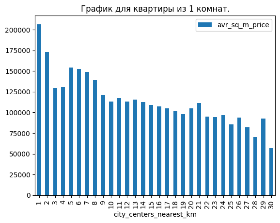

```
'Для'
```

```
'квартиры'
```

```
'из'
```

```
2
```

```
'комнат корреляция средней цены за один квадратный метр к расстоянию от центра в км составляет'
```

```
-0.5918081431260295
```

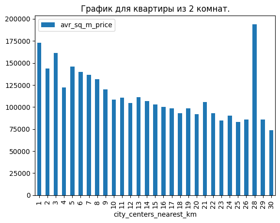

```
'Для'
```

```
'квартиры'
```

```
'из'
```

```
3
```

```
'комнат корреляция средней цены за один квадратный метр к расстоянию от центра в км составляет'
```

```
-0.9063552281866545
```

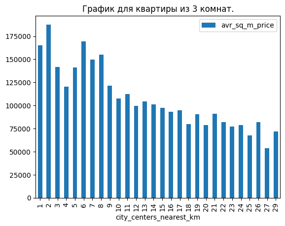

```
'Для'
```

```
'квартиры'
```

```
'из'
```

```
4
```

```
'комнат корреляция средней цены за один квадратный метр к расстоянию от центра в км составляет'
```

```
-0.7527731395382499
```

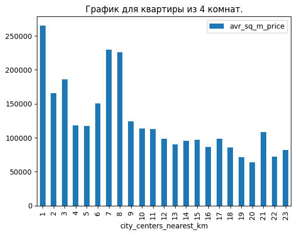

```
'Для'
```

```
'квартиры'
```

```
'из'
```

```
5
```

```
'комнат корреляция средней цены за один квадратный метр к расстоянию от центра в км составляет'
```

```
-0.8300264916339628
```

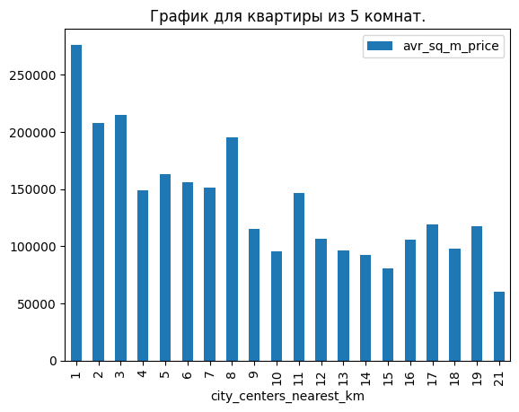

```
'Для'
```

```
'квартиры'
```

```
'из'
```

```
6
```

```
'комнат корреляция средней цены за один квадратный метр к расстоянию от центра в км составляет'
```

```
-0.3998714130927359
```

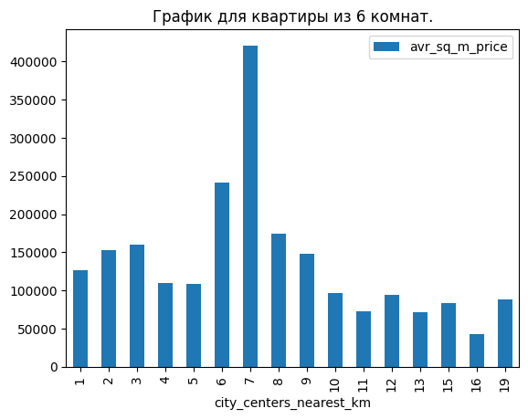

```
'Для'
```

```
'квартиры'
```

```
'из'
```

```
7
```

```
'комнат корреляция средней цены за один квадратный метр к расстоянию от центра в км составляет'
```

```
0.2552060908825834
```

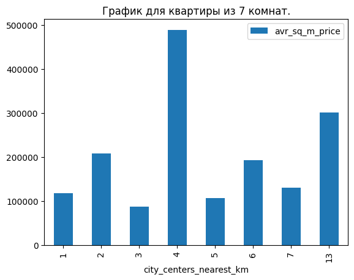

```
'Для'
```

```
'квартиры'
```

```
'из'
```

```
8
```

```
'комнат корреляция средней цены за один квадратный метр к расстоянию от центра в км составляет'
```

```
0.1140141697435897
```

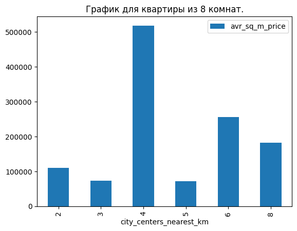

```
'Для'
```

```
'квартиры'
```

```
'из'
```

```
9
```

```
'комнат корреляция средней цены за один квадратный метр к расстоянию от центра в км составляет'
```

```
0.7231003684544546
```

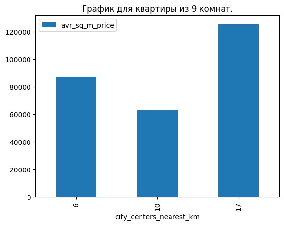

```
'Для'
```

```
'квартиры'
```

```
'из'
```

```
10
```

```
'комнат мало данных для расчета корреляция и построения графика'
```

```
'Для'
```

```
'квартиры'
```

```
'из'
```

```
11
```

```
'комнат мало данных для расчета корреляция и построения графика'
```

```
'Для'
```

```
'квартиры'
```

```
'из'
```

```
12
```

```
'комнат корреляция средней цены за один квадратный метр к расстоянию от центра в км составляет'
```

```
1.0
```

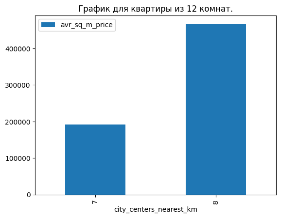

```
'Для'
```

```
'квартиры'
```

```
'из'
```

```
14
```

```
'комнат корреляция средней цены за один квадратный метр к расстоянию от центра в км составляет'
```

```
-1.0
```

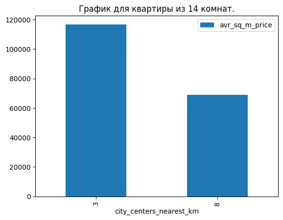

```
'Для'
```

```
'квартиры'
```

```
'из'
```

```
15
```

```
'комнат мало данных для расчета корреляция и построения графика'
```

```
'Для'
```

```
'квартиры'
```

```
'из'
```

```
16
```

```
'комнат мало данных для расчета корреляция и построения графика'
```

```
'Для'
```

```
'квартиры'
```

```
'из'
```

```
19
```

```
'комнат мало данных для расчета корреляция и построения графика'
```

```
'Для'
```

```
'студии'
```

```
'из'
```

```
0
```

```
'комнат корреляция средней цены за один квадратный метр к расстоянию от центра в км составляет'
```

```
-0.44476510412922343
```

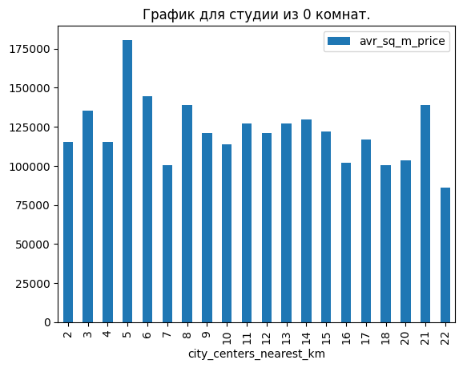

```python
for studio in data_spb_sq_m_price_km['studio'].unique():
    for rooms in data_spb_sq_m_price_km.query('studio == @studio')['rooms'].unique():
        df = data_spb_sq_m_price_km.query('studio == @studio and rooms == @rooms')
        cor = df['avr_sq_m_price'].corr(df['city_centers_nearest_km'])
        if pd.isna(cor):
            display ('Для' , studio, 'из', rooms, 'комнат мало данных для расчета корреляция и построения графика')
        else:
            display('Для' , studio, 'из', rooms, 'комнат корреляция средней цены за один квадратный метр к расстоянию от центра в км составляет', cor)
            barplot_name = 'График для '+studio+' из '+ str(rooms) +' комнат.'
            df.plot(x='city_centers_nearest_km',
                  y='avr_sq_m_price',
                  kind='bar',
                  title= barplot_name)
            plt.show()
```

**Вывод 2**: По данным выше можно более детально посмотреть. Но главное:

- мы можем подтвердить грубую оценку,
- мы можем добавить, что кроме центра так же ценится зона в 6-8 километрах от центра, далее цена снижается. Скорее всего из этого пояса удобно ездить на работу в будни и в центр в выходные.

**Выводы**:

- В базе мало сделок по 2014 году. Лучше эти данные не учитывать.
- Самые продуктивные: цены ниже, сделок больше, огромные суммы всех сделок за год, были в 2017 и 2018 годах.
- 2019 год: цены вверх, количество сделок вниз.

## Общий вывод

В данном исследовании мы выполнили следующие работы:

- разобрались с пропущенными значениями. Удаления были минимальны.
- оптимизировали данные, приведя их к удобным типам данных.
- поработали с аномалиями, неявнями дубликатами.
- посчитали и добавили новые столбцы, которые нам нужны для анализа.
- изучили и описали следующие параметры: -- общая площадь; -- жилая площадь; -- площадь кухни; -- цена объекта; -- количество комнат; -- высота потолков; -- этаж квартиры; -- тип этажа квартиры («первый», «последний», «другой»); -- общее количество этажей в доме; -- расстояние до центра города в метрах; -- расстояние до ближайшего аэропорта; -- расстояние до ближайшего парка; -- день и месяц публикации объявления.
- сделали анализ средней цены квадратного метра для 10 населённых пунктов.
- для Санкт-Петербурга изучили вопрос связанный с расстоянием от центра и ценой квадратного метра.

Из рассмотреного периода самый большой рынок (много сделок, более низкие цены) были 2017-2018 года.

На рынке есть эксклюзивы (расположение, большие площади), с ними нужно работать индивидуально. А остальные объекты, которых подовляющее большинство, должны быть в рамках зависимостей рассмотренных параметров.